# BIOS 6621 HW 2

Nathan Grove

9/12/2020

## IQ Values of Subjects Exposed to Lead by Distance

### Background

Lead is emitted from lead smelters and has the potential to be hazardous to children living in proximity to smelters. Lead exposure in sufficient quantities can affect almost every organ in the body.

Investigators examined the relationship between low-level lead exposure and high-level lead exposure on the IQ of children between the ages of 3 and 15 in El Paso. Investigators determined that subjects living within 1 mile of a lead smelter in the area would be considered as living “Near” the smelter, and subjects living outside of 1 mile of the smelter would be considered as living “Far” from the smelter. The IQ score of each subject was determined, and a summary of the data are presented below.

### Discussion of Error in IQ Value

Summary Statistics: IQ vs Distance

|  | n | Mean IQ | SD | Range |
| --- | --- | --- | --- | --- |
| Near | 57 | 89.19 | 12.17 | 59 |
| Far | 67 | 106.12 | 111.88 | 953 |

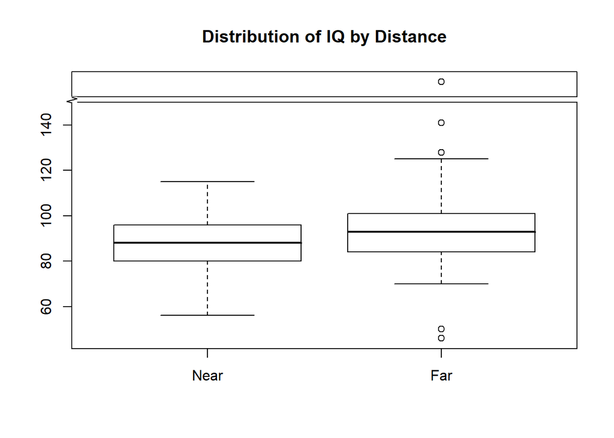

It can be seen above that the range of the Far group is more than an order of magnitude greater than the Near group. Subject 10, a member of the Far group has an IQ listed as 999. This value was entered by mistake and subject 10 should have an IQ value of 99. The code

```r
lead[10,2]<-99
```

corrects this value to 99, reflecting the correct IQ score for subject 10. Some background calculations not presented in the report thus far will need to be re-run to provide the following summary and tables with the corrected data.

```r
################################################################################
# Create submatrix according to "Near" or "Far"
Near_list<-lead[which(lead$Smelter=="Near"),]
Far_list<-lead[which(lead$Smelter=="Far"),]
################################################################################

################################################################################
# Create vector of IQ column of "Far_list" and
#   "Near_list", and combine that into new list "Distance_list
#   so gap.boxplot will make a boxplot with a gap in the y-axis.

Near_vect<-Near_list[,2]
Far_vect<-Far_list[,2]
Distance_list<-list(Near=Near_vect, Far=Far_vect)
################################################################################

################################################################################
# Means, SD, Range of Near_list and Far_list IQ, rounded to
#   2 decimal places
Mean_Near_IQ<-round((mean(Near_list$IQ)),
                    digits=2)
Mean_Far_IQ<-round((mean(Far_list$IQ)),
                    digits=2)

SD_Near_IQ<-round((sd(Near_list$IQ)),
                    digits=2)
SD_Far_IQ<-round((sd(Far_list$IQ)),
                    digits=2)

Range_Near_IQ<- max(Near_list$IQ)-
              min(Near_list$IQ)
Range_Far_IQ<- max(Far_list$IQ)-
              min(Far_list$IQ)
################################################################################

###############################################################################
#Creating matrix of summary statistics to be used in kbl() function

Distance_matrix<-matrix(rep(NA,8), nrow=2)

colnames(Distance_matrix)<-c("n", "Mean IQ", "SD", "Range")

rownames(Distance_matrix)<-c("Near", "Far")

# Col 1 n
Distance_matrix[1,1]<-length(Near_vect)
Distance_matrix[2,1]<-length(Far_vect)

# Col 2  mean
Distance_matrix[1,2]<-round(mean(Near_vect), digits=2)
Distance_matrix[2,2]<-round(mean(Far_vect), digits=2)

# Col 3 sd
Distance_matrix[1,3]<-round(sd(Near_vect), digits=2)
Distance_matrix[2,3]<-round(sd(Far_vect), digits=2)

# Col 4 range
Distance_matrix[1,4]<-max(Near_vect)- min(Near_vect)
Distance_matrix[2,4]<-max(Far_vect)- min(Far_vect)
###############################################################################
```

### Summary of Data

```r
# Creating kbl() table of Distance_matrix. Inputs variable with changes to data.

Distance_matrix %>%
  kbl(caption= "Summary Statistics: IQ vs Distance",
                  align="c") %>%
  kable_classic_2(full_width= FALSE, lightable_options= "striped",
                  font_size= 20)
```

Summary Statistics: IQ vs Distance

|  | n | Mean IQ | SD | Range |
| --- | --- | --- | --- | --- |
| Near | 57 | 89.19 | 12.17 | 59 |
| Far | 67 | 92.69 | 15.97 | 95 |

There were 57 subjects in the Near group, and 67 subjects in the Far goup. The mean IQ of the Near group is 89.19 and the mean IQ of the Far group is 92.69. The standard deviation of the Near group is 12.17 and the standard deviation of the Far group is 15.97. The range of the Near group is 59 and the range of the Far group is 95.

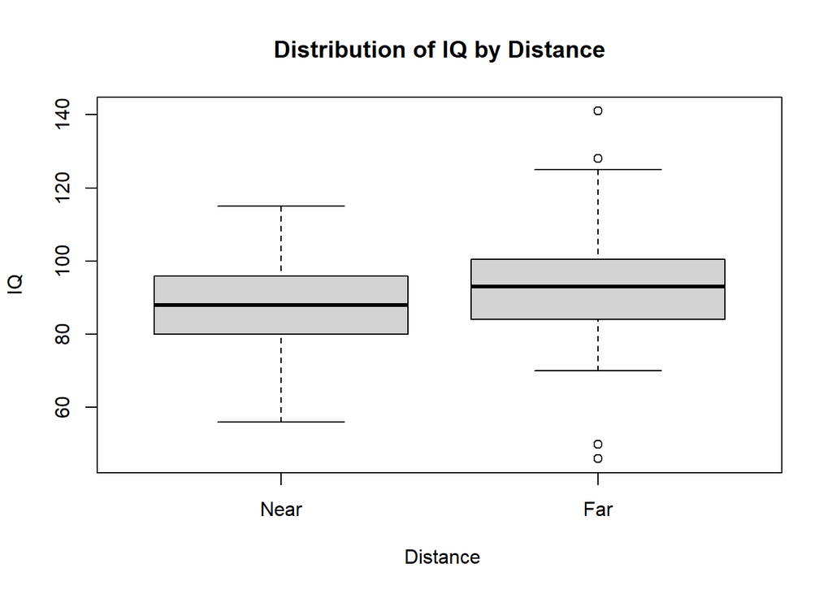

```r
# Boxplot of IQ values for Near and Far. If 999 outlier present, display
#   boxplot with gap in y axis to better display non-outlier data. If 999
#   outlier absent, display boxplot with standard scale.

if(max(lead$IQ==999)){

  gap.boxplot(Distance_list, gap=list(top=c(150,990), bottom=c(NA,NA)),
            names=c("Near","Far"), main="Distribution of IQ by Distance",
            ylab="IQ")

  axis.break(axis=2, breakpos=151, style="zigzag")

  } else {

    boxplot(Distance_list, main="Distribution of IQ by Distance",
            xlab=" Distance", ylab="IQ")}
```